# Minhas perguntas

Valter Lucena

3 de maio de 2018

Esta análise será realizada utilizando dados sobre avaliações de espisódios de séries presentes no [IMDB](https://www.imdb.com). Mais informações sobre esses dados podem ser encontradas [neste](https://github.com/nazareno/imdb-series) repositório do professor Nazareno Andrade.

# Escolha das séries e entendimento dos dados

Primeiramente, vamos importar os dados e selecionar as séries que serão analisadas.

```r
episodios = read_csv(here("data/series_from_imdb.csv"),
                    progress = FALSE,
                    col_types = cols(.default = col_double(),
                                     series_name = col_character(),
                                     episode = col_character(),
                                     url = col_character(),
                                     season = col_character()))
```

Resolvi analisar séries que possuem a mesma quantidade de temporadas e uma quantidade semelhante de episódios por temporada que *Game of Thrones*. Até a época onde esses dados foram coletados, existiam apenas informações sobre os episódios das suas 6 primeiras temporadas. Sabendo que cada temporada de *Game of Thrones* possui 10 episódios, vamos selecionar séries que possuem um número parecido de episódios por temporada.

```r
episodios %>%
    mutate(Série = series_name) %>%
    group_by(Série) %>%
    summarise(Temporadas = max(season),
              `Episódios por temporada` = max(season_ep)) %>%
    filter(Temporadas == 6,
           (`Episódios por temporada` >= 10),
           (`Episódios por temporada` <= 13))
```

| Série | Temporadas | Episódios por temporada |
| --- | --- | --- |
| American Horror Story | 6 | 13 |
| Drop Dead Diva | 6 | 13 |
| Game of Thrones | 6 | 10 |
| Girls | 6 | 12 |
| Homeland | 6 | 12 |
| Justified | 6 | 13 |
| Rookie Blue | 6 | 13 |
| The L Word | 6 | 13 |
| Veep | 6 | 10 |

Analisaremos, então, *American Horror Story*, *Game of Thrones* e *Homeland*.

```r
series_escolhidas = episodios %>%
    filter(series_name %in% c("American Horror Story",
                              "Game of Thrones",
                              "Homeland"))
```

# Perguntas

## Existe alguma relação entre o número de avaliações e avaliação geral das séries?

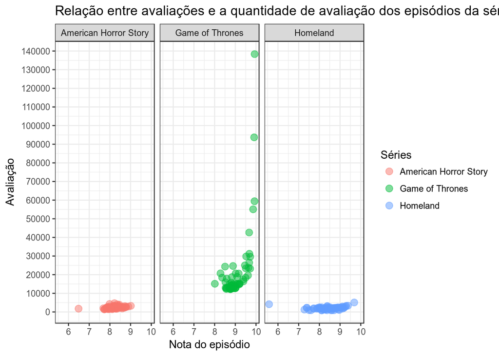

```r
series_escolhidas %>%
    mutate(Séries = series_name) %>%
    ggplot(aes(x = user_rating,
               y = user_votes,
               color = Séries)) +
    geom_jitter(alpha = .5,
                size = 3) +
    scale_y_continuous(breaks = seq(0, 150000, 10000)) +
    facet_wrap(~ series_name) +
    labs(title = "Relação entre avaliações e a quantidade de avaliação dos episódios da série",
         x = "Nota do episódio",
         y = "Avaliação")
```

Graficamente, podemos observar que *American Horror Story* e *Homeland* se comportam de forma parecida, com as avaliações mais concentradas entre 8 e 9 com menos de 10000 votantes. Já em *Game of Thrones*, percebe-se que todas as avaliações possuem notas maiores ou iguais a 8, e que esse valor aumenta com a quantidade de votos. Podemos usar, aqui, uma medida chamada **correlação** para verificar se duas variáveis se associam linearmente. Essa medida é um valor entre -1 e 1 e é classificada da seguinte forma:

- A associação é dita fraca se o módulo de seu valor aproxima-se de 0, e forte quando aproxima-se de 1.
- Se o valor da correlação é negativo, os valores de uma variável diminuem quando os da outra aumentam, e, se for positivo, aumentam quando os valores da outra variável também aumentam.

Utilizaremos a **correlação de Pearson** para isso, pois a mesma calcula a correlação entre duas variáveis contínuas.

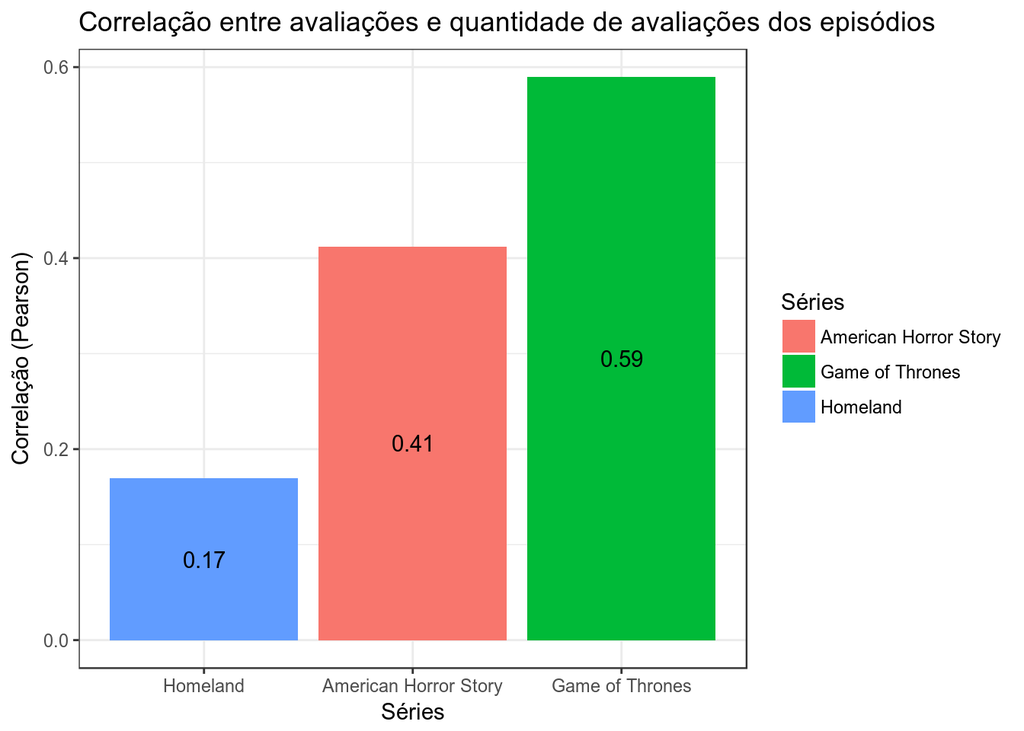

```r
series_escolhidas %>%
    group_by(series_name) %>%
    mutate(Séries = series_name,
           correlacao = cor(user_rating,
                            user_votes,
                            method = "pearson")) %>%
    ungroup() %>%
    select(Séries, correlacao) %>%
    unique() %>%
    ggplot(aes(x = reorder(Séries, correlacao),
               y = correlacao,
               fill = Séries,
               label = round(correlacao, 2))) +
    geom_col() +
    geom_text(position = position_stack(vjust = 0.5)) +
    labs(title = "Correlação entre avaliações e quantidade de avaliações dos episódios",
         x = "Séries",
         y = "Correlação (Pearson)")
```

Com esses valores, obtemos as seguintes informações:

- Para *Homeland* e *American Horror Story* a associação é fraca, sendo mais significativa em *American Horror Story* e bastante fraca em *Homeland*.
- Em *Game of Thrones*, a associação é moderadamente significativa, ainda que não seja tão forte.

Assim, podemos concluir que, para as séries analisadas, quanto maior a quantidade de votos, maior é avaliação da série. Esse aumento é mais forte em *American Horror Story* e *Game of Thrones* do que em *Homeland*, mas não é tão significativo.

É importante ressaltar, que, como a correlação calcula a associação linear entre as variáveis, a observação cuja quantidade de votos é menor que 10000 com uma avaliação um pouco maior que 5 faz com que a nuvem de pontos da série *Homeland* aproxime-se de uma reta horizontal, sendo esta, talvez, a possível causa para a correlação possuir um valor tão baixo. Vamos analisar mais de perto a série *Homeland* e tentar entender por que isso acontece.

### A quantidade de avaliações de *Homeland* mudou ao longo da série?

Vamos ver como as avaliações se comportam ao longo da série.

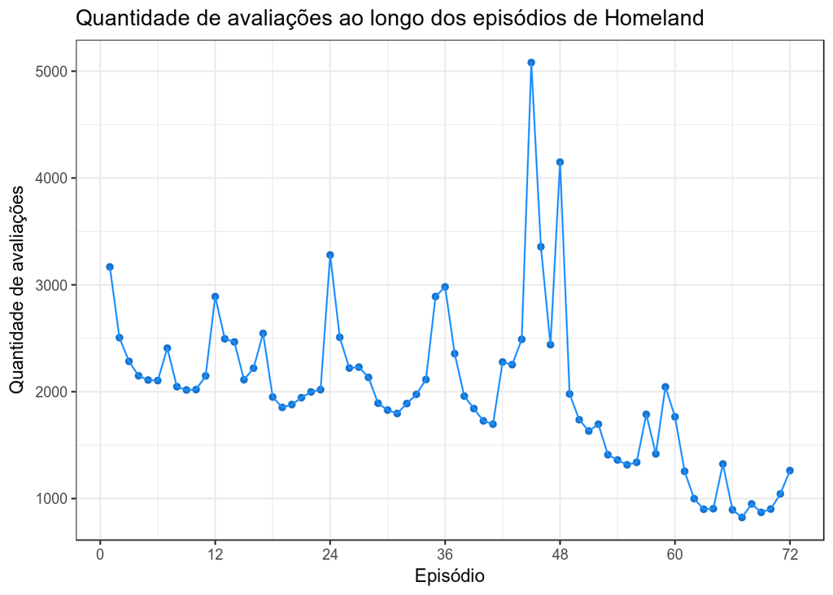

```r
series_escolhidas %>%
    filter(series_name %in% c("Homeland")) %>%
    ggplot(aes(x = series_ep,
               y = user_votes)) +
    geom_point(color = "dodgerblue3") +
    scale_x_continuous(breaks = seq(0, 72, 12)) +
    geom_line(color = "dodgerblue") +
    labs(title = "Quantidade de avaliações ao longo dos episódios de Homeland",
         x = "Episódio",
         y = "Quantidade de avaliações")
```

A partir do gráfico é possível perceber que a série possuía, mesmo com picos, uma quantidade parecida de votos para seus episódios até aproximadamente seu episódio 48, onde a quantidade começa a diminuir. Por fins de curiosidade, vejamos se o mesmo acontece com a avaliação da série.

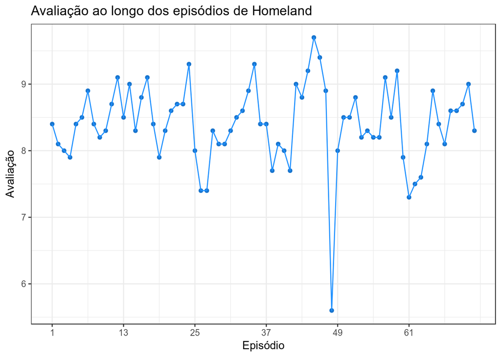

```r
series_escolhidas %>%
    filter(series_name %in% c("Homeland")) %>%
    ggplot(aes(x = series_ep,
               y = user_rating)) +
    geom_point(color = "dodgerblue3") +
    scale_x_continuous(breaks = seq(1, 72, 12)) +
    geom_line(color = "dodgerblue") +
    labs(title = "Avaliação ao longo dos episódios de Homeland",
         x = "Episódio",
         y = "Avaliação")
```

Como observado anteriormente com a quantidade de avaliações, a avaliação dos episódios mantêm-se numa faixa parecida até aproximadamente o episódio 48, mas aqui, a avaliação cai drasticamente. Acessando as [análises dos usuários](https://www.imdb.com/title/tt3952170/reviews) do episódio no [IMDB](https://www.imdb.com), uma opinião comum entre os que o avaliaram é de que este se trata do pior episódio da série.

É interessante observar como os dados refletem essas opiniões, pois, a partir dos dados, podemos concluir que o episódio mais mal avaliado da série é um dos que possuem a maior quantidade de avaliações, e, pelas opiniões dos usuários, que essas avaliações vêm de telespectadores da série que ficaram muito instatisfeitos com os acontecimentos do episódio.

## A temporada mais bem avaliada da série possui uma maior proporção de notas 10?

Vejamos, primeiramente, qual a temporada mais bem avaliada de cada série. A temporada mais bem avaliada aqui será a que possuir a maior nota entre as temporadas.

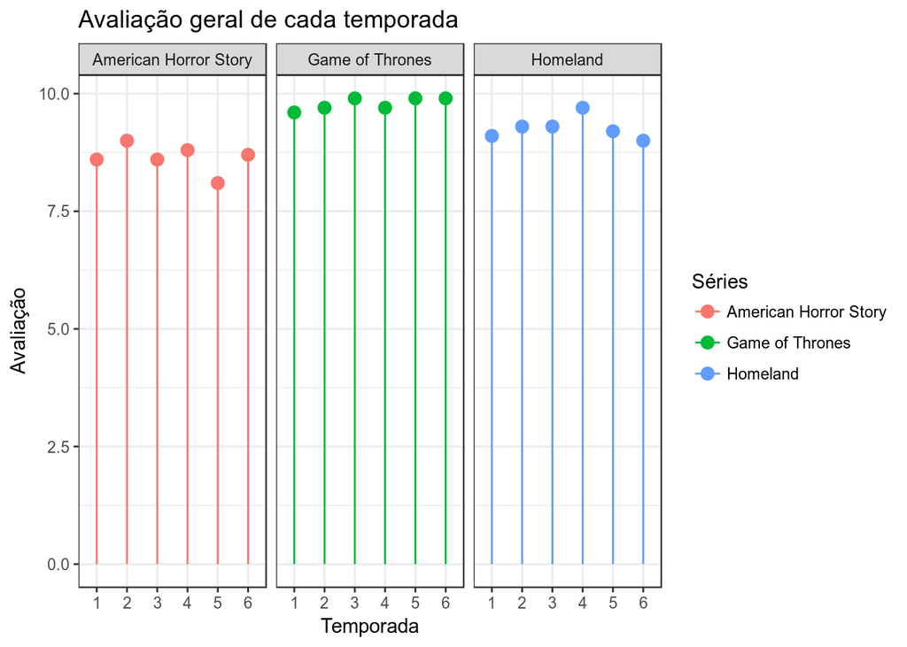

```r
series_escolhidas %>%
    group_by(series_name, season) %>%
    summarise(Avaliação = max(user_rating)) %>%
    ungroup() %>%
    select(series_name, season, Avaliação) %>%
    mutate(Séries = series_name, Temporada = season) %>%
    ggplot(aes(x = Temporada,
               y = Avaliação,
               color = Séries)) +
    geom_point(size = 3) +
    geom_segment(aes(x = Temporada,
                     xend = Temporada,
                     y = 0,
                     yend = Avaliação)) +
    facet_wrap(~Séries) +
    labs(title = "Avaliação geral de cada temporada")
```

Com o gráfico, observamos que as temporadas mais bem avaliadas de *American Horror Story*, *Game of Thrones* e *Homeland* são, respectivamente, a 2ª, 6ª e 4ª temporadas.

Observemos agora, como se comporta a proporção de notas 10 por temporada.

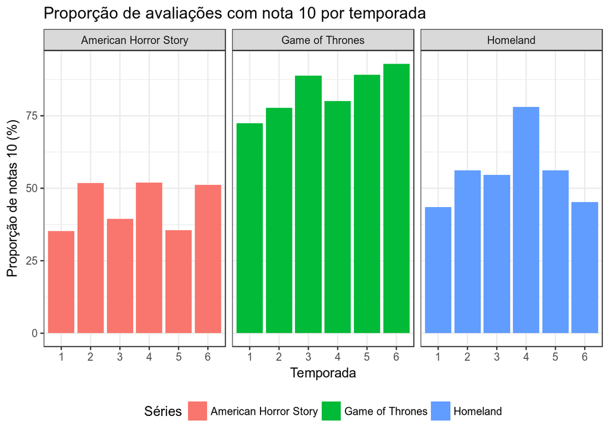

```r
series_escolhidas %>%
    mutate(Séries = series_name) %>%
    ggplot(aes(x = season,
               y = r10 * 100,
               fill = Séries)) +
    geom_col(position = "identity") +
    facet_wrap(~ series_name) +
    labs(title = "Proporção de avaliações com nota 10 por temporada",
         x = "Temporada",
         y = "Proporção de notas 10 (%)") +
    theme(legend.position = "bottom")
```

Se procurarmos neste gráfico, as temporadas mais bem avaliadas que encontramos no gráfico anterior, iremos perceber que essas temporadas são as que possuem a maior proporção de notas 10 (*Game of Thrones* e *Homeland*), ou se encontram entre as que possuem a maior proporção (*American Horror Story*).

Logo, é possível concluir, para as séries escolhidas, que a temporada mais bem avaliada de cada série possui uma maior proporção de avaliações com notas 10.

Como discutimos anteriormente, uma outra forma de verificar associação entre variáveis é utilizando a correlação. Vejamos, agora, se a conclusão que aqui chegamos mantém-se ao verificar a correlação entre a proporção de notas 10 e a avaliação da série.

### A avaliação da série está, de alguma forma, associada com a proporção de notas 10 que seus episódios recebem?

Primeiramente, vamos utilizar um gráfico de pontos para verificar a distribuição das observações.

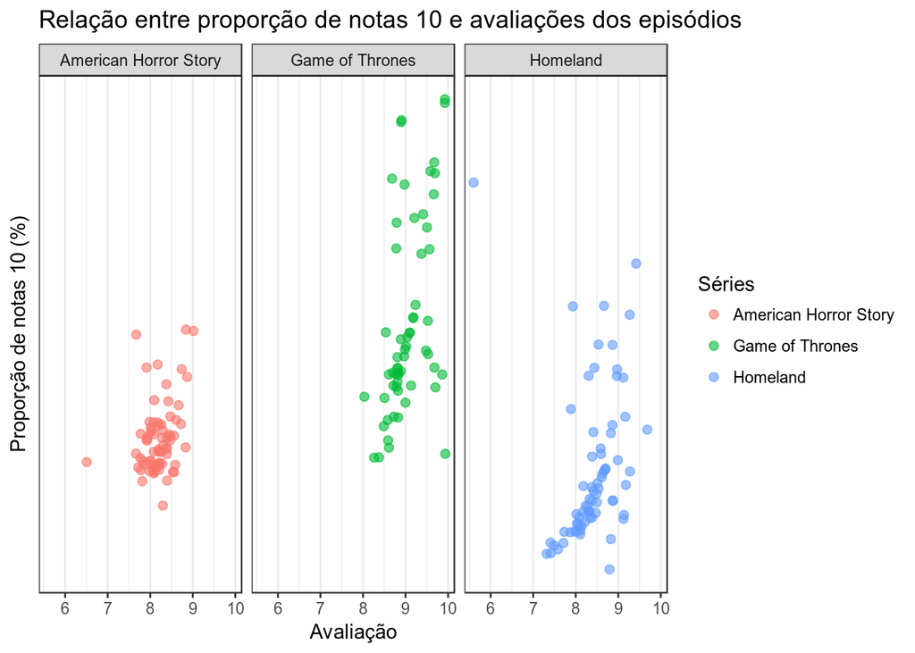

```r
series_escolhidas %>%
    mutate(Séries = series_name) %>%
    ggplot(aes(x = user_rating,
               y = r10 * 100,
               color = Séries)) +
    geom_jitter(alpha = .6,
                size = 2) +
    scale_y_continuous(breaks = seq(0, 1, 0.10)) +
    facet_wrap(~series_name) +
    labs(title = "Relação entre proporção de notas 10 e avaliações dos episódios",
         x = "Avaliação",
         y = "Proporção de notas 10 (%)")
```

Observamos, pelo gráfico, que a maioria das observações de *American Horror Story* concentram-se na mesma faixa de proporção para o mesmo intervalo de notas. A maioria dos episódios que possuem uma nota na faixa entre aproxidamente 7.5 e 9 possuem entre 20% e 40% de notas 10.

Em *Homeland*, essa proporção concentra-se entre 10% e 30% no intervalo de notas que vai de 7 até aproximadamente 9. Mais uma vez observamos o ponto destoante, que agora sabemos que pertence ao episódio 48. Uma observação a se fazer aqui é que, mesmo com quase 80% de notas 10, a avaliação do episódio ainda foi muito baixa.

Para *Game of Thrones*, os dados estão mais distruibuidos em relação a proporção, com todas as observações com notas entre 8 e 10.

Vejamos agora, a correlação linear entre a avaliação dos episódios e a proporção de notas 10. Utilizaremos a correlação de Pearson, também, pois as duas variáveis são contínuas.

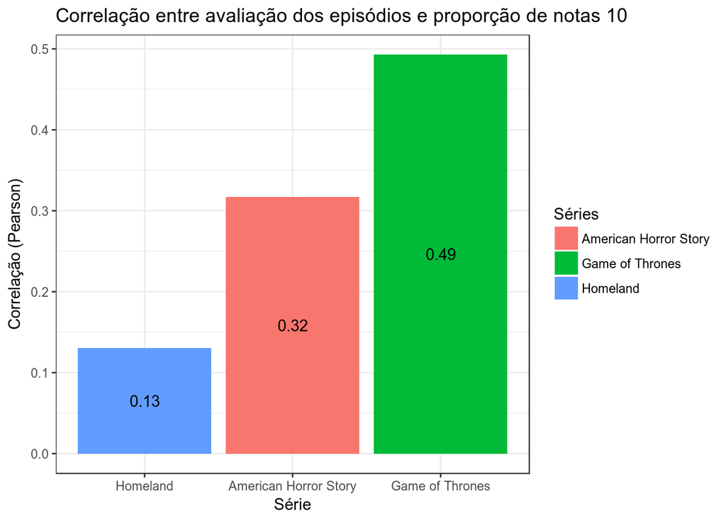

```r
series_escolhidas %>%
    group_by(series_name) %>%
    mutate(Séries = series_name,
           correlacao = cor(user_rating,
                            r10,
                            method = "pearson")) %>%
    ungroup() %>%
    select(Séries, correlacao) %>%
    unique() %>%
    ggplot(aes(x = reorder(Séries, correlacao),
               y = correlacao,
               fill = Séries,
               label = round(correlacao, 2))) +
    geom_col() +
    geom_text(position = position_stack(vjust = 0.5)) +
    labs(title = "Correlação entre avaliação dos episódios e proporção de notas 10",
         x = "Série",
         y = "Correlação (Pearson)")
```

Os resultados de correlação entre proporção de votos e avaliação e quantidade de votos e avaliação não mudam muito. Aqui, mais uma vez, observamos que o valor para *Homeland* aproxima-se de 0, que, entre outros fatores, pode ter sido causado pela avaliações do episódio 48, e para *American Horror Story* e *Game of Thrones*, o valor é um pouco maior e mais significativo, mas não tão significativo assim. A partir disso, concluímos que há uma associação entre a proporção de notas 10 dadas a um episódio da série, e a avaliação geral da mesma. Esta associação é muito fraca em *Homeland*, e moderatamente significativa em *American Horror Story* e *Game of Thrones*.